### I trust I can rely on your vote

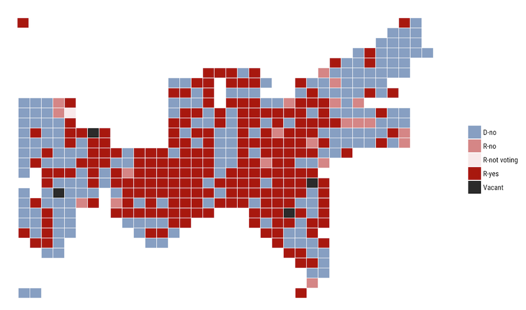

#### Part I

Use K-means clustering to identify the best 2, 3, and 4 clusterings of US states based on the data in the `poverty` data set. Use Euclidean distance for your similarity measure.

1. Find best cluster assignments of size $K$.
2. Generate a scatterplot of the 51 obs on their first two PCs.
3. Color code each obs with their cluster assignment. This should result in a total of 3 colored scatterplots. What does each cluster appear to represent? (You can add labels to the points using `geom_text(aes(label = state), vjust = 2))`).
4. Create a scree plot that compares clusters for $K$ from 1 to 5. Does the structure in the data suggest a clear number of clusters?

#### Part II

The American legislative process generates reams of data. Several public and non-profit groups track and diseminate this data. A prolific programmer and data scientist named Bob Rudis has built a package called `voteogram` that can be used to pull this data very easily into R (`voteogram` is installed on the server but can be installed locally from github using the `devtools` package).

1. The workhorse function of the `voteogram` package is the `roll_call()` function, which pulls down the data one bill at a time. Pull down the data from the House, the 115th congress, the first session, role call vote number 637.
   - What was the name of the bill?
   - When was it voted upon?
   - Did it pass? By what margin?
   - How did the Oregon congressmen and woman vote?
   - Using the code posted in the readme [here](https://github.com/hrbrmstr/voteogram), construct a cartogram (or voteogram?) for this vote.
2. Now let’s see if there are trends in the voting patterns over the past 50 votes. First, we need to build a dataframe that has all of the votes from all 435 congressmen and women so far this year. That involves looping over the `roll_call()` function as we work through the last 50 votes and storing each vote record as a column in a new dataframe called `votes`. This will take just a minute or two. We print out the vote number that it’s currently pulling down so that you can keep track of the progress.

```r
votes <- matrix(NA, nrow = 435, ncol = 50)
rcall_ind <- 588:637

for(i in 1:length(rcall_ind)) {
  print(rcall_ind[i])
  votes[, i] <- roll_call("house", 115, 1, rcall_ind[i])$votes$position
}

vote_yes <- votes == "Yes"
```

What is the dimensionality of `votes`? What is the difference between `votes` and `vote_yes`?

3. Run k-means clustering on the voting records to identify two clusters of legislators based on their voting patterns. How well do these clusters cohere with party affiliation?
4. Re-run k-means with 1, 3, 4, 5, and 6 clusters and construct a scree plot of the total within SS as a function of $k$. What does this tell us about the scale of clustering in voting patterns on these 50 bills?
5. Using the same technique from part I, plot the legislators on the first two principle component scores and color code them by their cluster membership in one of four clusters. Add labels indicating the party membership of each legislator.
6. In general, when performing PCA or another dimension reduction technique on data like this, what could we expect to learn from the loadings of the first several principle components?
7. **Challenge problem:** what do these particular first two principle components appear to be coding for? Note that this analysis could be improved both on the clustering and the dimension reduction side by using an alternate distance or similarity metrix.